# R Notebook

Download the package needed for analyzing

```r
library(ggplot2)
library(readr)
library(reshape2)
library(tidyr)
library(dplyr)
library(emmeans)
if (!require(ggsignif)) install.packages("ggsignif")
library(ggsignif)  # For significance bars

sample_size = 35 # For each group, there are 35 individuals to match the needs of power and effect size.
```

Simulating Sample - Without Intervention

```r
participants <- rep(1:35, each = 3)
stage <- rep(c("Pre", "Mid", "Post"), times = 35) # Each participant does the questionnaire 3 times in total during the three stages of season (pre-season, mid-season and post-season)

# Generate normally distributed scores (range is 4-20)
somatic_score_c <- pmin(pmax(round(rnorm(35 * 3, mean = 12, sd = 4)), 4), 20)
worry_score_c <- pmin(pmax(round(rnorm(35 * 3, mean = 12, sd = 4)), 4), 20)
concentration_c <- pmin(pmax(round(rnorm(35 * 3, mean = 12, sd = 4)), 4), 20)

# Save into a table
data_control <- data.frame(
  Participants = participants,
  Somatic_Score = somatic_score_c,
  Worry_Score = worry_score_c,
  Concentration = concentration_c,
  Stage = stage
)
```

Simulating Sample - With Intervention

```r
participants <- rep(1:35, each = 3)
stage <- rep(c("Pre", "Mid", "Post"), times = 35)# Each participant does the questionnaire 3 times in total during the three stages of season (pre-season, mid-season and post-season)

# Generate normally distributed scores (range is 4-20)
somatic_score_p <- pmin(pmax(round(rnorm(35 * 3, mean = 11, sd = 4)), 4), 20)
worry_score_p <- pmin(pmax(round(rnorm(35 * 3, mean = 10.5, sd = 4)), 4), 20)
concentration_p <- pmin(pmax(round(rnorm(35 * 3, mean = 10, sd = 4)), 4), 20)

# Save into a table
data_exp <- data.frame(
  Participants = participants,
  Somatic_Score = somatic_score_p,
  Worry_Score = worry_score_p,
  Concentration = concentration_p,
  Stage = stage
)
```

Clean the missing data - If the participants fail to finish one stage of three, their data will be removed. - If any of these three scores is less than 4 or greater than 20 due to any technical issue, the participant’s data will be removed.

1. Clean Control Group

```r
# Identify missing data with NA and data outside the valid range
invalid_participants_c <- unique(data_control$Participants[
  is.na(data_control$Somatic_Score) | is.na(data_control$Worry_Score) | is.na(data_control$Concentration) |
  data_control$Somatic_Score < 4 | data_control$Somatic_Score > 20 |
  data_control$Worry_Score < 4 | data_control$Worry_Score > 20 |
  data_control$Concentration < 4 | data_control$Concentration > 20
])

# Save the cleaned data frame
Clean_control <- data_control[!data_control$Participants %in% invalid_participants_c, ]
```

2. Clean Experiment Group

```r
# Identify missing data with NA and data outside the valid range
invalid_participants_p <- unique(data_exp$Participants[
  is.na(data_exp$Somatic_Score) | is.na(data_exp$Worry_Score) | is.na(data_exp$Concentration) |
  data_exp$Somatic_Score < 4 | data_exp$Somatic_Score > 20 |
  data_exp$Worry_Score < 4 | data_exp$Worry_Score > 20 |
  data_exp$Concentration < 4 | data_exp$Concentration > 20
])

# Save the cleaned data frame
Clean_exp <- data_exp[!data_exp$Participants %in% invalid_participants_p, ]
```

Explore and summarize the data.

```r
head(Clean_control)
```

|  | Participants | Somatic_Score | Worry_Score | Concentration | Stage |
| --- | --- | --- | --- | --- | --- |
| 1 | 1 | 14 | 9 | 7 | Pre |
| 2 | 1 | 12 | 9 | 16 | Mid |
| 3 | 1 | 11 | 8 | 11 | Post |
| 4 | 2 | 14 | 12 | 14 | Pre |
| 5 | 2 | 12 | 17 | 19 | Mid |
| 6 | 2 | 15 | 4 | 15 | Post |

```r
head(Clean_exp)
```

|  | Participants | Somatic_Score | Worry_Score | Concentration | Stage |
| --- | --- | --- | --- | --- | --- |
| 1 | 1 | 10 | 4 | 10 | Pre |
| 2 | 1 | 7 | 18 | 8 | Mid |
| 3 | 1 | 10 | 16 | 9 | Post |
| 4 | 2 | 12 | 9 | 11 | Pre |
| 5 | 2 | 14 | 4 | 6 | Mid |
| 6 | 2 | 12 | 15 | 14 | Post |

```r
summary(Clean_control)
```

```
  Participants Somatic_Score    Worry_Score    Concentration     Stage
 Min.   : 1    Min.   : 4.00   Min.   : 4.00   Min.   : 4.0   Length:105
 1st Qu.: 9    1st Qu.:10.00   1st Qu.: 9.00   1st Qu.:10.0   Class :character
 Median :18    Median :12.00   Median :12.00   Median :12.0   Mode  :character
 Mean   :18    Mean   :12.37   Mean   :12.03   Mean   :12.2
 3rd Qu.:27    3rd Qu.:15.00   3rd Qu.:15.00   3rd Qu.:15.0
 Max.   :35    Max.   :20.00   Max.   :20.00   Max.   :20.0
```

```r
summary(Clean_exp)
```

```
  Participants Somatic_Score    Worry_Score    Concentration      Stage
 Min.   : 1    Min.   : 4.00   Min.   : 4.00   Min.   : 4.00   Length:105
 1st Qu.: 9    1st Qu.: 8.00   1st Qu.: 7.00   1st Qu.: 7.00   Class :character
 Median :18    Median :11.00   Median :10.00   Median :10.00   Mode  :character
 Mean   :18    Mean   :10.96   Mean   :10.22   Mean   :10.02
 3rd Qu.:27    3rd Qu.:14.00   3rd Qu.:13.00   3rd Qu.:13.00
 Max.   :35    Max.   :20.00   Max.   :20.00   Max.   :20.00
```

```r
# Get the sum of three scores
data_control$Total_Score <- data_control$Somatic_Score + data_control$Worry_Score + data_control$Concentration
data_exp$Total_Score <- data_exp$Somatic_Score + data_exp$Worry_Score + data_exp$Concentration

# Mean of Control group
# Pre-Season stage
contMean_pre <- colMeans(Clean_control[Clean_control$Stage == "Pre", c("Somatic_Score", "Worry_Score", "Concentration")], na.rm = TRUE)

# Mid-Season stage
contMean_mid <- colMeans(Clean_control[Clean_control$Stage == "Mid", c("Somatic_Score", "Worry_Score", "Concentration")], na.rm = TRUE)

# Mid-Season stage
contMean_post <- colMeans(Clean_control[Clean_control$Stage == "Post", c("Somatic_Score", "Worry_Score", "Concentration")], na.rm = TRUE)


# Mean of experiment group
# Pre-Season stage
expMean_pre <- colMeans(Clean_exp[Clean_exp$Stage == "Pre", c("Somatic_Score", "Worry_Score", "Concentration")], na.rm = TRUE)

# Mid-Season stage
expMean_mid <- colMeans(Clean_exp[Clean_exp$Stage == "Mid", c("Somatic_Score", "Worry_Score", "Concentration")], na.rm = TRUE)

# Mid-Season stage
expMean_post <- colMeans(Clean_exp[Clean_exp$Stage == "Post", c("Somatic_Score", "Worry_Score", "Concentration")], na.rm = TRUE)
```

- Get sd and SE of 2 groups

```r
# Get the sum of scores
# For Control group
cont_pre <- rowSums(Clean_control[Clean_control$Stage == "Pre", c("Somatic_Score", "Worry_Score", "Concentration")], na.rm = TRUE)
cont_mid <- rowSums(Clean_control[Clean_control$Stage == "Mid", c("Somatic_Score", "Worry_Score", "Concentration")], na.rm = TRUE)
cont_post <- rowSums(Clean_control[Clean_control$Stage == "Post", c("Somatic_Score", "Worry_Score", "Concentration")], na.rm = TRUE)

# For Experiment group
exp_pre <- rowSums(Clean_exp[Clean_exp$Stage == "Pre", c("Somatic_Score", "Worry_Score", "Concentration")], na.rm = TRUE)
exp_mid <- rowSums(Clean_exp[Clean_exp$Stage == "Mid", c("Somatic_Score", "Worry_Score", "Concentration")], na.rm = TRUE)
exp_post <- rowSums(Clean_exp[Clean_exp$Stage == "Post", c("Somatic_Score", "Worry_Score", "Concentration")], na.rm = TRUE)

# Calculate SD and SE and save them with means into a table
sd <- data.frame(
  Stage = factor(rep(c("Pre", "Mid", "Post"), each = 2), levels = c("Pre", "Mid", "Post")),
  Group = rep(c("Control", "Experiment"), 3),
  Mean = c(mean(cont_pre), mean(exp_pre),
            mean(cont_mid), mean(exp_mid),
            mean(cont_post), mean(exp_post)),
  SD = c(sd(cont_pre), sd(exp_pre),
         sd(cont_mid), sd(exp_mid),
         sd(cont_post), sd(exp_post)),
  n = c(length(cont_pre), length(exp_pre),
        length(cont_mid), length(exp_mid),
        length(cont_post), length(exp_post))
)

# Calculate standard error
sd$SE <- sd$SD / sqrt(sd$n)
print(sd)
```

| Stage | Group | Mean | SD | n | SE |
| --- | --- | --- | --- | --- | --- |
| Pre | Control | 37.97143 | 6.519138 | 35 | 1.101935 |
| Pre | Experiment | 31.65714 | 6.786417 | 35 | 1.147114 |
| Mid | Control | 36.54286 | 8.627394 | 35 | 1.458296 |
| Mid | Experiment | 30.28571 | 7.290491 | 35 | 1.232318 |
| Post | Control | 35.28571 | 6.061311 | 35 | 1.024549 |
| Post | Experiment | 31.65714 | 6.187953 | 35 | 1.045955 |

Save into 2 tables to compare 1. Control group

```r
# Combine the mean values into a matrix
contMeans_table <- rbind(contMean_pre, contMean_mid, contMean_post)

# Assign row and column names
rowc <- rownames(contMeans_table) <- c("Pre-Season", "Mid-Season", "Post-Season")
colc <- colnames(contMeans_table) <- c("Somatic_Score", "Worry_Score", "Concentration")

# Convert to a data frame for better readability
contMeans_table <- as.data.frame(contMeans_table)
print(contMeans_table)
```

|  | Somatic_Score | Worry_Score | Concentration |
| --- | --- | --- | --- |
| Pre-Season | 12.77143 | 12.20000 | 13.00000 |
| Mid-Season | 12.05714 | 12.65714 | 11.82857 |
| Post-Season | 12.28571 | 11.22857 | 11.77143 |

2. Experiment Group

```r
# Combine the mean values into a matrix
expMeans_table <- rbind(expMean_pre, expMean_mid, expMean_post)

# Assign row and column names
rowe <- rownames(expMeans_table) <- c("Pre-Season", "Mid-Season", "Post-Season")
cole <- colnames(expMeans_table) <- c("Somatic_Score", "Worry_Score", "Concentration")

# Convert to a data frame for better readability
expMeans_table <- as.data.frame(expMeans_table)
print(expMeans_table)
```

|  | Somatic_Score | Worry_Score | Concentration |
| --- | --- | --- | --- |
| Pre-Season | 11.20000 | 10.514286 | 9.942857 |
| Mid-Season | 10.54286 | 10.228571 | 9.514286 |
| Post-Season | 11.14286 | 9.914286 | 10.600000 |

Visualization

1. Compare the three scores across three stages in 2 groups.

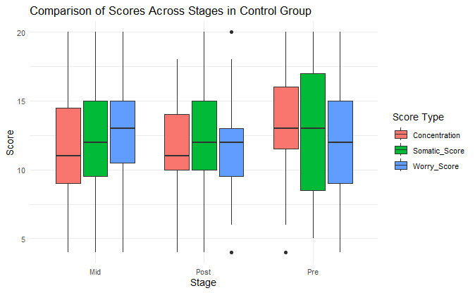

```r
# Control Group
control_long <- tidyr::gather(Clean_control, key = "Score_Type", value = "Score", Somatic_Score, Worry_Score, Concentration)
boxplot_control <- ggplot(control_long, aes(x = Stage, y = Score, fill = Score_Type)) +
  geom_boxplot() +
  theme_minimal() +
  labs(title = "Comparison of Scores Across Stages in Control Group", x = "Stage", y = "Score", fill = "Score Type")

# Print the boxplot
print(boxplot_control)
```

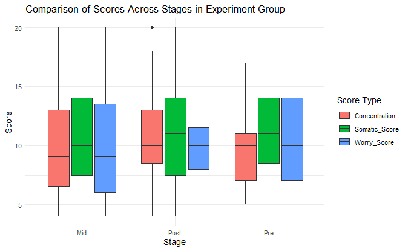

```r
# Experiment Group
exp_long <- tidyr::gather(Clean_exp, key = "Score_Type", value = "Score", Somatic_Score, Worry_Score, Concentration)
boxplot_exp <- ggplot(exp_long, aes(x = Stage, y = Score, fill = Score_Type)) +
  geom_boxplot() +
  theme_minimal() +
  labs(title = "Comparison of Scores Across Stages in Experiment Group", x = "Stage", y = "Score", fill = "Score Type")

# Print the boxplot
print(boxplot_exp)
```

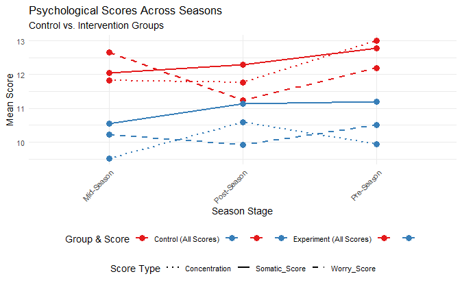

```r
# Make both tables have Group identifiers (added to your existing code)
contMeans_table$Group <- "Control"
expMeans_table$Group <- "Experiment"

contMeans_table$Stage <- rownames(contMeans_table)
expMeans_table$Stage <- rownames(expMeans_table)

# Combine the tables
combined_data <- rbind(contMeans_table, expMeans_table)

# Convert to long format
long_data <- pivot_longer(combined_data,
                         cols = c(Somatic_Score, Worry_Score, Concentration),
                         names_to = "Score_Type",
                         values_to = "Value")

# Create the combined plot
ggplot(long_data, aes(x = Stage, y = Value,
                     color = interaction(Group, Score_Type),
                     linetype = Score_Type,
                     group = interaction(Group, Score_Type))) +
  geom_line(linewidth = 1) +
  geom_point(size = 3) +
  scale_color_manual(
    name = "Group & Score",
    values = c(
      "Control.Somatic_Score" = "#E41A1C",  # Red
      "Control.Worry_Score" = "#E41A1C",     # Same red
      "Control.Concentration" = "#E41A1C",   # Same red
      "Experiment.Somatic_Score" = "#377EB8", # Blue
      "Experiment.Worry_Score" = "#377EB8",   # Same blue
      "Experiment.Concentration" = "#377EB8"  # Same blue
    ),
    labels = c(
      "Control (All Scores)",
      "", "",  # Empty labels to avoid duplicates
      "Experiment (All Scores)",
      "", ""
    )
  ) +
  scale_linetype_manual(
    name = "Score Type",
    values = c(
      "Somatic_Score" = "solid",
      "Worry_Score" = "dashed",
      "Concentration" = "dotted"
    )
  ) +
  labs(
    title = "Psychological Scores Across Seasons",
    subtitle = "Control vs. Intervention Groups",
    x = "Season Stage",
    y = "Mean Score"
  ) +
  theme_minimal() +
  theme(
    legend.position = "bottom",
    legend.box = "vertical",
    legend.spacing.y = unit(0.2, "cm"),
    axis.text.x = element_text(angle = 45, hjust = 1)
  ) +
  guides(
    color = guide_legend(order = 1, nrow = 1),
    linetype = guide_legend(order = 2)
  )
```

Inferential Stats